# RandomForest

## Random forest and time series forecasting

```python
from numpy import asarray
import pandas as pd
from pandas import read_csv
from pandas import DataFrame
from pandas import concat
from sklearn.metrics import mean_absolute_error
from sklearn.ensemble import RandomForestRegressor
from sklearn.ensemble import GradientBoostingRegressor
from matplotlib import pyplot
from statsmodels.tsa.holtwinters import ExponentialSmoothing
import pandas as pd
from datetime import date
import numpy as np
import datetime
```

Подготовим данные. Нам понадобится колонка 'VOL' с объемами торгов. Выделим ее.

```python
series = pd.read_csv('GAZP.csv', header=0, index_col=0)
data = pd.DataFrame()
data.index = series.index+' '+series['TIME']
series.index = series.index+' '+series['TIME']
data = pd.concat([data,series['VOL']],axis = 1)
series.head()
```

|  | TIME | OPEN | HIGH | LOW | CLOSE | VOL |
| --- | --- | --- | --- | --- | --- | --- |
| 02/20/23 11:00:00 | 11:00:00 | 153.63 | 153.86 | 152.02 | 152.47 | 2759380 |
| 02/20/23 12:00:00 | 12:00:00 | 152.47 | 152.78 | 152.00 | 152.01 | 1562270 |
| 02/20/23 13:00:00 | 13:00:00 | 152.04 | 152.08 | 152.00 | 152.08 | 1394820 |
| 02/20/23 14:00:00 | 14:00:00 | 152.08 | 152.08 | 151.62 | 152.08 | 1681800 |
| 02/20/23 15:00:00 | 15:00:00 | 152.07 | 152.08 | 151.65 | 152.08 | 659170 |

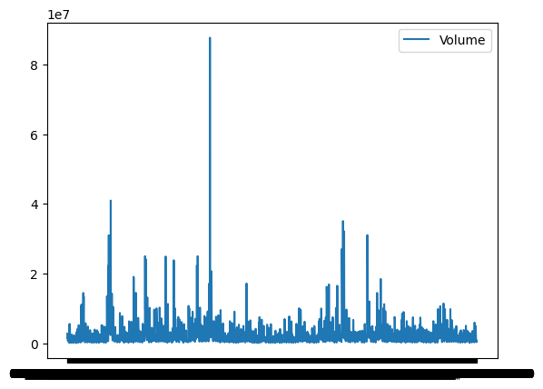

|  | VOL |
| --- | --- |
| 02/20/23 11:00:00 | 2759380 |
| 02/20/23 12:00:00 | 1562270 |
| 02/20/23 13:00:00 | 1394820 |
| 02/20/23 14:00:00 | 1681800 |
| 02/20/23 15:00:00 | 659170 |

```python
#pyplot.close()
pyplot.plot(data['VOL'], label='Volume')
pyplot.legend(loc='best')
pyplot.show()
data.head()
```

Мы будем исследовать и строить прогноз для часового ряда объемов торгов. Прежде всего проверим, что ряд стационарный с помощью теста Дика-Фуллера. Напомним, что основная гипотеза состоит в том, ряд нестационарный

```python
from statsmodels.tsa.stattools import adfuller

def check_stationarity(series):

    result = adfuller(series.values)

    print('ADF Statistic: %f' % result[0])
    print('p-value: %f' % result[1])
    print('Critical Values:')
    for key, value in result[4].items():
        print('\t%s: %.3f' % (key, value))

    if (result[1] <= 0.05) & (result[4]['5%'] > result[0]):
        print("\u001b[32mStationary\u001b[0m")
    else:
        print("\x1b[31mNon-stationary\x1b[0m")
```

```python
check_stationarity(data['VOL'])
```

```
ADF Statistic: -6.743802
p-value: 0.000000
Critical Values:
	1%: -3.433
	5%: -2.863
	10%: -2.567
Stationary
```

Итак, ряд стационарный. Посмотрим на ACF ряда.

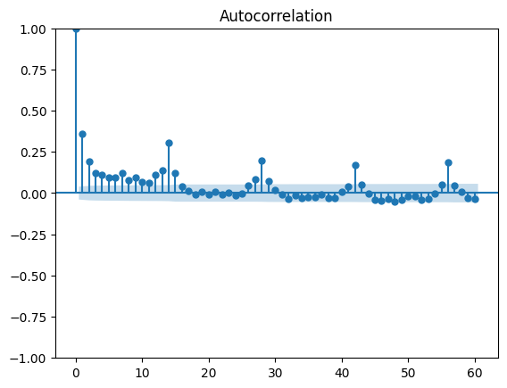

```python
from statsmodels.graphics.tsaplots import plot_acf
plot_acf(data['VOL'],lags=60,alpha = 0.05)
```

Периодически повторяющиеся всплески ACF через каждые 14 лагов говорят нам о наличии сезонной компоненты с периодом 14. Но именно столько часов работы Московской биржи в сутки с часов 10:00 утра до 24-00.

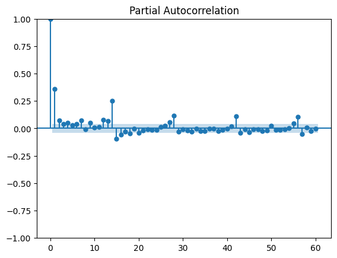

```python
from statsmodels.graphics.tsaplots import plot_pacf
plot_pacf(data['VOL'],lags=60,alpha = 0.05,method='ywm')
```

Аналогичную картину дает и PACF, что также подтверждает наш вывод о сезонности.

Подготовим входной набор данных. Для учета влияния данных отстоящих по времени на один час необходимо сдвинуть данные на 1 час,учета отстоящих на 2 часа - сдвинуть на 2 часа и т.д.

```python
data.shift(1).head()
```

|  | VOL |
| --- | --- |
| 02/20/23 11:00:00 | NaN |
| 02/20/23 12:00:00 | 2759380.0 |
| 02/20/23 13:00:00 | 1562270.0 |
| 02/20/23 14:00:00 | 1394820.0 |
| 02/20/23 15:00:00 | 1681800.0 |

```python
data.shift(2).head()
```

|  | VOL |
| --- | --- |
| 02/20/23 11:00:00 | NaN |
| 02/20/23 12:00:00 | NaN |
| 02/20/23 13:00:00 | 2759380.0 |
| 02/20/23 14:00:00 | 1562270.0 |
| 02/20/23 15:00:00 | 1394820.0 |

Аналогично для построения прогноза на 1 час вперед. Нужен сдвинутый по времени выходной ряд. Только сдвигать надо в обратную сторону.

```python
data.shift(-1).head()
```

|  | VOL |
| --- | --- |
| 02/20/23 11:00:00 | 1562270.0 |
| 02/20/23 12:00:00 | 1394820.0 |
| 02/20/23 13:00:00 | 1681800.0 |
| 02/20/23 14:00:00 | 659170.0 |
| 02/20/23 15:00:00 | 986730.0 |

Итак для учета всего периода сезонности надо провести 14 сдвигов вперед и для прогноза 1 сдвиг в эту же сторону. Попутно уберем строки с NAN. Что и сделает следущая функция. Таким образом получим матрицу, где каждая строка первых 14 колонок содержит данные в моменты времени t,t+1,...t+13,а последняя колонка данные на момент времени t+14.

```python
# transform a time series dataset into a supervised learning dataset
def series_to_supervised(data, n_in=1, n_out=1, dropnan=True):
    n_vars = 1 if type(data) is list else data.shape[1]
    df = pd.DataFrame(data)
    cols = list()
    # input sequence (t-n, ... t-1)
    for i in range(n_in, 0, -1):
        cols.append(df.shift(i))
    # forecast sequence (t, t+1, ... t+n)
    for i in range(0, n_out):
        cols.append(df.shift(-i))
    # put it all together
    agg = pd.concat(cols, axis=1)
    # drop rows with NaN values
    if dropnan:
        agg.dropna(inplace=True)
    return agg.values
# spl
```

```python
n_in=14
mydata = series_to_supervised(data, n_in=n_in, n_out=1, dropnan=True)
pd.DataFrame(mydata).head()
```

|  | 0 | 1 | 2 | 3 | 4 | 5 | 6 | 7 | 8 | 9 | 10 | 11 | 12 | 13 | 14 |
| --- | --- | --- | --- | --- | --- | --- | --- | --- | --- | --- | --- | --- | --- | --- | --- |
| 0 | 2759380.0 | 1562270.0 | 1394820.0 | 1681800.0 | 659170.0 | 986730.0 | 1543880.0 | 1827860.0 | 1142460.0 | 454830.0 | 368380.0 | 334230.0 | 423590.0 | 147220.0 | 5556130.0 |
| 1 | 1562270.0 | 1394820.0 | 1681800.0 | 659170.0 | 986730.0 | 1543880.0 | 1827860.0 | 1142460.0 | 454830.0 | 368380.0 | 334230.0 | 423590.0 | 147220.0 | 5556130.0 | 1664090.0 |
| 2 | 1394820.0 | 1681800.0 | 659170.0 | 986730.0 | 1543880.0 | 1827860.0 | 1142460.0 | 454830.0 | 368380.0 | 334230.0 | 423590.0 | 147220.0 | 5556130.0 | 1664090.0 | 5441790.0 |
| 3 | 1681800.0 | 659170.0 | 986730.0 | 1543880.0 | 1827860.0 | 1142460.0 | 454830.0 | 368380.0 | 334230.0 | 423590.0 | 147220.0 | 5556130.0 | 1664090.0 | 5441790.0 | 3129210.0 |
| 4 | 659170.0 | 986730.0 | 1543880.0 | 1827860.0 | 1142460.0 | 454830.0 | 368380.0 | 334230.0 | 423590.0 | 147220.0 | 5556130.0 | 1664090.0 | 5441790.0 | 3129210.0 | 814230.0 |

Подготовлено 14 входных рядов и 1 выходной ряд. Теперь можно приступить к построению случайного леса.

После того, как набор данных подготовлен, мы должны быть осторожны с тем, как он используется для подбора и оценки модели.

Например, было бы неправильно строить модель на данных из будущего и предсказывать прошлое. Модель должна обучаться на прошлом и прогнозировать будущее.

Это означает, что методы, которые рандомизируют набор данных во время оценки, такие как перекрестная проверка в k-кратном размере , не могут быть использованы. Вместо этого мы должны использовать технику, называемую прямой проверкой.

При прямой проверке набор данных сначала разбивается на обучающий и тестовый наборы путем выбора точки отсечения, например, все данные, за исключением последних 14 часов, используются для обучения, а последние 14 часов используются для тестирования.

```python
# split a univariate dataset into train/test sets
def train_test_split(data, n_test):
    return data[:-n_test, :], data[-n_test:, :]
```

Следующая функция оценивает модель случайного леса для задач регрессии

```python
def random_forest_forecast(train, testX):
    # transform list into array
    train = asarray(train)
    # split into input and output columns
    trainX, trainy = train[:, :-1], train[:, -1]
    # fit model
    isBoost = False
    if isBoost==False :
        model = RandomForestRegressor(n_estimators=1000)
        model.fit(trainX, trainy)
    else:
        model= GradientBoostingRegressor(n_estimators=1000).fit(trainX, trainy)
    # make a one-step prediction
    yhat = model.predict([testX])
    return yhat[0]
```

Функция осуществляет прямую проверку прогнозов и вычисляет средний модуля ощибки (mae).

```python
# walk-forward validation for univariate data
def walk_forward_validation(data, n_test):
    predictions = list()
    # split dataset
    train, test = train_test_split(data, n_test)
    # seed history with training dataset
    history = [x for x in train]
    # step over each time-step in the test set
    for i in range(len(test)):
        # split test row into input and output columns
        testX, testy = test[i, :-1], test[i, -1]
        # fit model on history and make a prediction
        yhat = random_forest_forecast(history, testX)
        # store forecast in list of predictions
        predictions.append(yhat)
        # add actual observation to history for the next loop
        history.append(test[i])
        # summarize progress
        print('>expected=%.1f, predicted=%.1f' % (testy, yhat))
    # estimate prediction error
    error = mean_absolute_error(test[:, -1], predictions)
    return error, test[:, -1], predictions
```

```python
import time
t0 = time.time()
n_in=14
values = data.values

data = series_to_supervised(values, n_in=n_in,n_out=1)


mae, y, yhat = walk_forward_validation(data, n_in)
t = datetime.timedelta(seconds=time.time()-t0)
print(f'Time: {t}')
```

```
>expected=5951080.0, predicted=2122402.7
>expected=2750380.0, predicted=3994859.9
>expected=2269990.0, predicted=2068094.0
>expected=1398920.0, predicted=1754063.7
>expected=977380.0, predicted=1748060.8
>expected=743600.0, predicted=1238495.5
>expected=781730.0, predicted=1416131.5
>expected=4952660.0, predicted=2917026.4
>expected=2843920.0, predicted=2378638.5
>expected=1328340.0, predicted=1394122.1
>expected=362250.0, predicted=936384.2
>expected=925710.0, predicted=496186.2
>expected=606570.0, predicted=1174289.1
>expected=557230.0, predicted=977875.9
Time: 0:08:21.873329
```

```python
data = pd.DataFrame()
data = pd.concat([data,series['VOL']],axis = 1)
data.index = series.index
test =  pd.DataFrame(data).iloc[len(data['VOL'])-n_in:, 0]
```

Для сравнения построим прогноз на 14 часов методом Хольта-Винтерса с аддитивной сезонной компонентой.

```python
test =  data.iloc[len(data['VOL'])-14:, 0]
t0 = time.time()
model = ExponentialSmoothing(data['VOL'],  trend='add', seasonal='add',  seasonal_periods=14)
hw_model = model.fit()
pred = hw_model.predict(start=test.index[0], end=test.index[-1])
t = datetime.timedelta(seconds=time.time()-t0)
print(f'Time: {t}')
```

```
Time: 0:00:01.267227
```

Средний модуль ошибки у Holt-Winters меньше. А по времени счета Holt-Winters вне конкуренции.

```python
hw_error = mean_absolute_error(test, pred)
print('MAE Holt-Winters: %.3f' % hw_error)
print('MAE Random Forest: %.3f' % mae)
```

```
MAE Holt-Winters: 849105.090
MAE Random Forest: 863492.488
```

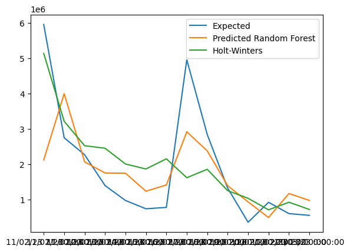

```python
pyplot.close()
pyplot.plot(test.index,y, label='Expected')
pyplot.plot(test.index,yhat, label='Predicted Random Forest')
pyplot.plot(pred.index, pred, label='Holt-Winters')
pyplot.legend(loc='best')
pyplot.show()
```